# Exploratory Analysis

# Preamble

## Load Packages

Here we load packages and set options for this notebook.

```r
library(tidyverse)
```

## Load data

```r
# Load the dataframe
data_dir <- "/Users/robertarbon/Google Drive/Courses/Analysis-best-practice/data/original"
f_name <- paste0(data_dir, '/dili_from_anti_TB_treatment.csv')
df <- read.csv(f_name, stringsAsFactors = FALSE)
str(df)
```

```
'data.frame':   305 obs. of  20 variables:
 $ id                    : int  1 2 3 4 5 6 7 8 9 10 ...
 $ pdili                 : int  1 1 1 1 1 1 1 1 1 1 ...
 $ t1dili                : int  1 1 0 1 1 1 1 1 1 1 ...
 $ agegroup              : chr  "30/39" "30/39" "30/39" "40+" ...
 $ sex                   : chr  "F" "F" "M" "M" ...
 $ weight                : num  67 51.6 63.1 83 76.2 55 57.8 56.4 56.5 46.6 ...
 $ rifam_dpw             : num  8.96 11.63 9.51 7.23 7.87 ...
 $ ison_dpw              : num  4.48 5.81 4.75 3.61 3.94 ...
 $ pyraz_dpw             : num  22.4 29.1 15.8 18.1 26.2 ...
 $ moxi_dpw              : num  NA NA NA 4.82 5.25 ...
 $ hiv                   : int  0 0 0 0 0 0 1 0 0 0 ...
 $ hcv                   : int  0 NA 1 0 0 0 0 0 0 0 ...
 $ hbv                   : int  0 NA 0 0 0 0 0 0 0 0 ...
 $ alcohol               : int  0 0 NA 1 NA 0 1 NA NA 1 ...
 $ liver_disease         : int  0 0 1 0 0 0 0 0 0 0 ...
 $ tb_site               : int  2 2 1 2 2 1 2 3 2 1 ...
 $ log10base_alt         : num  1.462 0.699 1.146 1.491 1.204 ...
 $ log10base_alp         : num  1.74 1.8 2 1.79 1.9 ...
 $ log10base_bili        : num  1 0.778 0.699 1.114 0.903 ...
 $ time_to_onset_of_pDILI: int  55 8 50 91 14 2 9 11 34 2 ...
```

# Descriptive statistics

- In order to describe our data we’re going to use packages from the [`tidyverse`](https://www.tidyverse.org/).
- This is a suite of packages in `R` which make handling data particularly easy and intuitive.
- The equivalent in `python` is [`Pandas`](https://pandas.pydata.org/) with [`seaborn`](https://seaborn.pydata.org/).
- This notebook will take you through reproducing two tables from the paper as well as other summary statistics.
- We will focus on reproducing the information content rather than nicely formatting a table.

## Baseline characteristics

### Factor variables

Let’s try to do an analysis similar to the first part of table 1 from the paper.

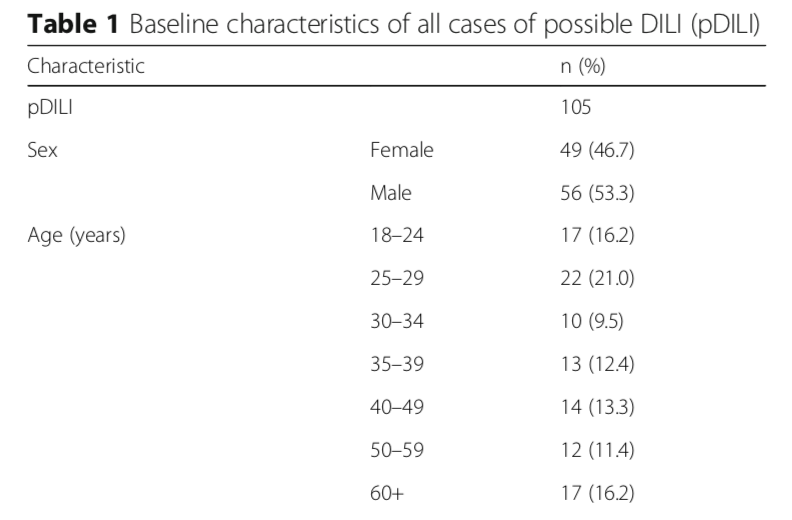

First three characteristics from Table 1

The first characteristic is the number of cases of possible drug induced liver injury, `pDILI`. There are a number of ways we could do this.

In the `pDILI` column, `1` represents a possible case, so simply summing that column will give us the number of cases:

```r
sum(df$pdili)
```

```
[1] 105
```

If `pdili` was a factor variable then we couldn’t just sum.

```r
df$pdili <- as.factor(df$pdili)
sum(df$pdili)
```

```
Error in Summary.factor(c(2L, 2L, 2L, 2L, 2L, 2L, 2L, 2L, 2L, 2L, 2L,  :
  ‘sum’ not meaningful for factors
```

In order to summarize factors (and any other variable) we’ll need:

- [`summarise`](https://dplyr.tidyverse.org/reference/summarise.html) and
- [`group_by`](https://dplyr.tidyverse.org/reference/group_by.html)

from the [`dplyr`](https://dplyr.tidyverse.org/) package.

`summarise` requires a dataframe and a summary statistic. The summary statistic in this case is just the number of observations (`n()`)

```r
summarise(df, num_obs=n())
```

| num_obs |
| --- |
| 305 |

By itself, this has just told us the number of rows in the dataframe. Now lets add in `group_by`. This groups the dataframe by the levels in variable you specify, so let’s specify `pdili` (the `head` function just shows the top of the dataframe)

```r
head(group_by(df, pdili))
```

| id | pdili | t1dili | agegroup | sex | weight | rifam_dpw | ison_dpw | pyraz_dpw | moxi_dpw | hiv | hcv | hbv | alcohol | liver_disease | tb_site | log10base_alt | log10base_alp | log10base_bili | time_to_onset_of_pDILI |
| --- | --- | --- | --- | --- | --- | --- | --- | --- | --- | --- | --- | --- | --- | --- | --- | --- | --- | --- | --- |
| 1 | 1 | 1 | 30/39 | F | 67.0 | 8.955224 | 4.477612 | 22.38806 | NA | 0 | 0 | 0 | 0 | 0 | 2 | 1.462398 | 1.740363 | 1.0000000 | 55 |
| 2 | 1 | 1 | 30/39 | F | 51.6 | 11.627907 | 5.813953 | 29.06977 | NA | 0 | NA | NA | 0 | 0 | 2 | 0.698970 | 1.799341 | 0.7781513 | 8 |
| 3 | 1 | 0 | 30/39 | M | 63.1 | 9.508717 | 4.754358 | 15.84786 | NA | 0 | 1 | 0 | NA | 1 | 1 | 1.146128 | 2.000000 | 0.6989700 | 50 |
| 4 | 1 | 1 | 40+ | M | 83.0 | 7.228916 | 3.614458 | 18.07229 | 4.819277 | 0 | 0 | 0 | 1 | 0 | 2 | 1.491362 | 1.792392 | 1.1139433 | 91 |
| 5 | 1 | 1 | 40+ | F | 76.2 | 7.874016 | 3.937008 | 26.24672 | 5.249344 | 0 | 0 | 0 | NA | 0 | 2 | 1.204120 | 1.897627 | 0.9030900 | 14 |
| 6 | 1 | 1 | 18/29 | M | 55.0 | 10.909091 | 5.454546 | 27.27273 | NA | 0 | 0 | 0 | 0 | 0 | 1 | 1.724276 | 1.491362 | 1.1139433 | 2 |

By itself, it doesn’t do anything, it just allows other functions to use the dataframes in groups. So let’s use it with summarise.

```r
tmp <- group_by(df, pdili)
summarise(tmp, n_obs=n())
```

| pdili | n_obs |
| --- | --- |
| 0 | 200 |
| 1 | 105 |

You can of course shorten this to a single line of code by doing:

```r
summarise(group_by(df, pdili), n_obs=n())
```

| pdili | n_obs |
| --- | --- |
| 0 | 200 |
| 1 | 105 |

The downside to this is that when you want to chain many functions, this kind of pattern becomes very unweildy. So we have the `%>%` operator which allows you to write `f(x,y)` as `x %>% f(y)`:

```r
df %>% group_by(pdili) %>% summarise(n=n())
```

| pdili | n |
| --- | --- |
| 0 | 200 |
| 1 | 105 |

This is the pattern we’ll use from now on.

What about the other variables? You can give `group_by` as many variables (column names) as you like, so let’s try that:

```r
df %>% group_by(pdili, sex, agegroup) %>% summarise(n_obs=n())
```

| pdili | sex | agegroup | n_obs |
| --- | --- | --- | --- |
| 0 | F | 18/29 | 28 |
| 0 | F | 30/39 | 21 |
| 0 | F | 40+ | 36 |
| 0 | M | 18/29 | 36 |
| 0 | M | 30/39 | 37 |
| 0 | M | 40+ | 42 |
| 1 | F | 18/29 | 17 |
| 1 | F | 30/39 | 12 |
| 1 | F | 40+ | 20 |
| 1 | M | 18/29 | 22 |

[output cut: 2 more lines]

This is interesting but not **quite** what we want. When you give `group_by` a list of variables you group in a hierarchy specified by the order of the variables in the function (`pdili` at the top, `agegroup` at the bottom).

We’d like to keep the first column above (the `pdili` column) but after that we’d like a `characteristic` column which has `sex` and `agegroup`, then a `level` column which specifies the levels in `sex` and `agegroup` and then last of all the `n_obs` column which counts the instances in each level. Something like this:

| pdili | characteristic | level | n_obs |
| --- | --- | --- | --- |
| 1 | sex | F | ? |
| 1 | sex | M | ? |
| 1 | agegroup | 18/29 | ? |
| … | … | … | … |
| 0 | agegroup | 29/39 | ? |
| 0 | agegroup | 40+ | ? |

To do this we’re going to use the [`gather`](https://tidyr.tidyverse.org/reference/gather.html) from another `tidyverse` package, [`tidyr`](https://tidyr.tidyverse.org). `gather` puts variable names into a `key` column and its values into a `value` column. You’ll need to look at the far right hand side of the dataframe to see what it’s done.

```r
df %>% gather(key='characteristic', value='level', sex) %>% head()
```

|  | id | pdili | t1dili | agegroup | weight | rifam_dpw | ison_dpw | pyraz_dpw | moxi_dpw | hiv | hcv | hbv | alcohol | liver_disease | tb_site | log10base_alt | log10base_alp | log10base_bili | time_to_onset_of_pDILI | characteristic | level |
| --- | --- | --- | --- | --- | --- | --- | --- | --- | --- | --- | --- | --- | --- | --- | --- | --- | --- | --- | --- | --- | --- |
| 1 | 1 | 1 | 1 | 30/39 | 67.0 | 8.955224 | 4.477612 | 22.38806 | NA | 0 | 0 | 0 | 0 | 0 | 2 | 1.462398 | 1.740363 | 1.0000000 | 55 | sex | F |
| 2 | 2 | 1 | 1 | 30/39 | 51.6 | 11.627907 | 5.813953 | 29.06977 | NA | 0 | NA | NA | 0 | 0 | 2 | 0.698970 | 1.799341 | 0.7781513 | 8 | sex | F |
| 3 | 3 | 1 | 0 | 30/39 | 63.1 | 9.508717 | 4.754358 | 15.84786 | NA | 0 | 1 | 0 | NA | 1 | 1 | 1.146128 | 2.000000 | 0.6989700 | 50 | sex | M |
| 4 | 4 | 1 | 1 | 40+ | 83.0 | 7.228916 | 3.614458 | 18.07229 | 4.819277 | 0 | 0 | 0 | 1 | 0 | 2 | 1.491362 | 1.792392 | 1.1139433 | 91 | sex | M |
| 5 | 5 | 1 | 1 | 40+ | 76.2 | 7.874016 | 3.937008 | 26.24672 | 5.249344 | 0 | 0 | 0 | NA | 0 | 2 | 1.204120 | 1.897627 | 0.9030900 | 14 | sex | F |
| 6 | 6 | 1 | 1 | 18/29 | 55.0 | 10.909091 | 5.454546 | 27.27273 | NA | 0 | 0 | 0 | 0 | 0 | 1 | 1.724276 | 1.491362 | 1.1139433 | 2 | sex | M |

When you just give it one variable, all that happens is an extra column is created and some names are shifted about.

Let’s give it a list of column names and see what happens, again check the far right of the dataframe.

```r
tmp <- df %>% gather(key='characteristic', value='level', c(sex, agegroup))
head(tmp)
```

|  | id | pdili | t1dili | weight | rifam_dpw | ison_dpw | pyraz_dpw | moxi_dpw | hiv | hcv | hbv | alcohol | liver_disease | tb_site | log10base_alt | log10base_alp | log10base_bili | time_to_onset_of_pDILI | characteristic | level |
| --- | --- | --- | --- | --- | --- | --- | --- | --- | --- | --- | --- | --- | --- | --- | --- | --- | --- | --- | --- | --- |
| 1 | 1 | 1 | 1 | 67.0 | 8.955224 | 4.477612 | 22.38806 | NA | 0 | 0 | 0 | 0 | 0 | 2 | 1.462398 | 1.740363 | 1.0000000 | 55 | sex | F |
| 2 | 2 | 1 | 1 | 51.6 | 11.627907 | 5.813953 | 29.06977 | NA | 0 | NA | NA | 0 | 0 | 2 | 0.698970 | 1.799341 | 0.7781513 | 8 | sex | F |
| 3 | 3 | 1 | 0 | 63.1 | 9.508717 | 4.754358 | 15.84786 | NA | 0 | 1 | 0 | NA | 1 | 1 | 1.146128 | 2.000000 | 0.6989700 | 50 | sex | M |
| 4 | 4 | 1 | 1 | 83.0 | 7.228916 | 3.614458 | 18.07229 | 4.819277 | 0 | 0 | 0 | 1 | 0 | 2 | 1.491362 | 1.792392 | 1.1139433 | 91 | sex | M |
| 5 | 5 | 1 | 1 | 76.2 | 7.874016 | 3.937008 | 26.24672 | 5.249344 | 0 | 0 | 0 | NA | 0 | 2 | 1.204120 | 1.897627 | 0.9030900 | 14 | sex | F |
| 6 | 6 | 1 | 1 | 55.0 | 10.909091 | 5.454546 | 27.27273 | NA | 0 | 0 | 0 | 0 | 0 | 1 | 1.724276 | 1.491362 | 1.1139433 | 2 | sex | M |

The dimensions have gone from 305, 20 to 610, 20.

Let’s save ourselves the problem of constantly looking at columns we’re not interested in and use [`select`](https://dplyr.tidyverse.org/reference/select.html) function:

```r
df %>%
  gather(key='characteristic', value='level', c(sex, agegroup)) %>%
  select(c(pdili, characteristic, level)) %>%
  head()
```

|  | pdili | characteristic | level |
| --- | --- | --- | --- |
| 1 | 1 | sex | F |
| 2 | 1 | sex | F |
| 3 | 1 | sex | M |
| 4 | 1 | sex | M |
| 5 | 1 | sex | F |
| 6 | 1 | sex | M |

This looks like it could be useful now. Now we can use `group_by` to group by `pdili` and `characteristic` and then use `summarise` to count the number of the observations in each level.

```r
df %>%
  gather(key='characteristic', value='level', c(sex, agegroup)) %>%
  select(c(pdili, characteristic, level)) %>%
  group_by(pdili, characteristic, level) %>%
  summarise(n_obs=n())
```

| pdili | characteristic | level | n_obs |
| --- | --- | --- | --- |
| 0 | agegroup | 18/29 | 64 |
| 0 | agegroup | 30/39 | 58 |
| 0 | agegroup | 40+ | 78 |
| 0 | sex | F | 85 |
| 0 | sex | M | 115 |
| 1 | agegroup | 18/29 | 39 |
| 1 | agegroup | 30/39 | 23 |
| 1 | agegroup | 40+ | 43 |
| 1 | sex | F | 49 |
| 1 | sex | M | 56 |

In table 1 (unlike table 2) we’re not interested in the `pdili=0` case. So let’s use `filter` to remove those observations:

```r
df %>%
  gather(key='characteristic', value='level', c(sex, agegroup)) %>%
  select(c(pdili, characteristic, level)) %>%
  group_by(pdili, characteristic, level) %>%
  summarise(n_obs=n()) %>%
  filter(pdili==1)
```

| pdili | characteristic | level | n_obs |
| --- | --- | --- | --- |
| 1 | agegroup | 18/29 | 39 |
| 1 | agegroup | 30/39 | 23 |
| 1 | agegroup | 40+ | 43 |
| 1 | sex | F | 49 |
| 1 | sex | M | 56 |

```r
head(df)
```

|  | id | pdili | t1dili | agegroup | sex | weight | rifam_dpw | ison_dpw | pyraz_dpw | moxi_dpw | hiv | hcv | hbv | alcohol | liver_disease | tb_site | log10base_alt | log10base_alp | log10base_bili | time_to_onset_of_pDILI |
| --- | --- | --- | --- | --- | --- | --- | --- | --- | --- | --- | --- | --- | --- | --- | --- | --- | --- | --- | --- | --- |
| 1 | 1 | 1 | 1 | 30/39 | F | 67.0 | 8.955224 | 4.477612 | 22.38806 | NA | 0 | 0 | 0 | 0 | 0 | 2 | 1.462398 | 1.740363 | 1.0000000 | 55 |
| 2 | 2 | 1 | 1 | 30/39 | F | 51.6 | 11.627907 | 5.813953 | 29.06977 | NA | 0 | NA | NA | 0 | 0 | 2 | 0.698970 | 1.799341 | 0.7781513 | 8 |
| 3 | 3 | 1 | 0 | 30/39 | M | 63.1 | 9.508717 | 4.754358 | 15.84786 | NA | 0 | 1 | 0 | NA | 1 | 1 | 1.146128 | 2.000000 | 0.6989700 | 50 |
| 4 | 4 | 1 | 1 | 40+ | M | 83.0 | 7.228916 | 3.614458 | 18.07229 | 4.819277 | 0 | 0 | 0 | 1 | 0 | 2 | 1.491362 | 1.792392 | 1.1139433 | 91 |
| 5 | 5 | 1 | 1 | 40+ | F | 76.2 | 7.874016 | 3.937008 | 26.24672 | 5.249344 | 0 | 0 | 0 | NA | 0 | 2 | 1.204120 | 1.897627 | 0.9030900 | 14 |
| 6 | 6 | 1 | 1 | 18/29 | M | 55.0 | 10.909091 | 5.454546 | 27.27273 | NA | 0 | 0 | 0 | 0 | 0 | 1 | 1.724276 | 1.491362 | 1.1139433 | 2 |

And actually, I want `agegroup` to be at the bottom - so let’s (re)`arrange` them so it’s at the bottom by having the variables in descending order. We’ll also save this dataframe for the next part.

```r
df_nobs <- df %>%
  gather(key='characteristic', value='level', c(sex, agegroup)) %>%
  select(c(pdili, characteristic, level)) %>%
  group_by(pdili, characteristic, level) %>%
  summarise(n_obs=n()) %>%
  filter(pdili==1) %>%
  arrange(desc(characteristic))
df_nobs
```

| pdili | characteristic | level | n_obs |
| --- | --- | --- | --- |
| 1 | sex | F | 49 |
| 1 | sex | M | 56 |
| 1 | agegroup | 18/29 | 39 |
| 1 | agegroup | 30/39 | 23 |
| 1 | agegroup | 40+ | 43 |

Now that we’ve got the number of observations in each category we need to add the proportion of the total observations that they represent. We could create a new column equal to `n_obs` and divide by 105.

However a more elegant solution, which would take into account missing values, is to calculate the group totals (the total for group `sex` and group `agegroup`) and divide by that number.

The way we create new variables is using the [`mutate`](https://dplyr.tidyverse.org/reference/mutate.html) from [`dplyr`](https://dplyr.tidyverse.org/). The arguments are specified as `[new variable name] = formula()`. As usual, if we give it a dataframe that has been parsed through `group_by` the formula acts on each group separately.

```r
df_nobs %>%
  group_by(characteristic) %>%
  mutate(total=sum(n_obs))
```

| pdili | characteristic | level | n_obs | total |
| --- | --- | --- | --- | --- |
| 1 | sex | F | 49 | 105 |
| 1 | sex | M | 56 | 105 |
| 1 | agegroup | 18/29 | 39 | 105 |
| 1 | agegroup | 30/39 | 23 | 105 |
| 1 | agegroup | 40+ | 43 | 105 |

Now we can divide `n_obs` by `total`:

```r
df_nobs %>%
  group_by(characteristic) %>%
  mutate(total=sum(n_obs)) %>%
  mutate(proportion = n_obs/total*100)
```

| pdili | characteristic | level | n_obs | total | proportion |
| --- | --- | --- | --- | --- | --- |
| 1 | sex | F | 49 | 105 | 46.66667 |
| 1 | sex | M | 56 | 105 | 53.33333 |
| 1 | agegroup | 18/29 | 39 | 105 | 37.14286 |
| 1 | agegroup | 30/39 | 23 | 105 | 21.90476 |
| 1 | agegroup | 40+ | 43 | 105 | 40.95238 |

if you want less decimal places, just adjust your formula:

```r
df_nobs %>%
  group_by(characteristic) %>%
  mutate(total=sum(n_obs)) %>%
  mutate(proportion = as.character(round(n_obs/total*100, 1)))
```

| pdili | characteristic | level | n_obs | total | proportion |
| --- | --- | --- | --- | --- | --- |
| 1 | sex | F | 49 | 105 | 46.7 |
| 1 | sex | M | 56 | 105 | 53.3 |
| 1 | agegroup | 18/29 | 39 | 105 | 37.1 |
| 1 | agegroup | 30/39 | 23 | 105 | 21.9 |
| 1 | agegroup | 40+ | 43 | 105 | 41 |

### Numerical variables

We can use similar techniques to summarise numerical variables as well. Let’s look at part of table 2:

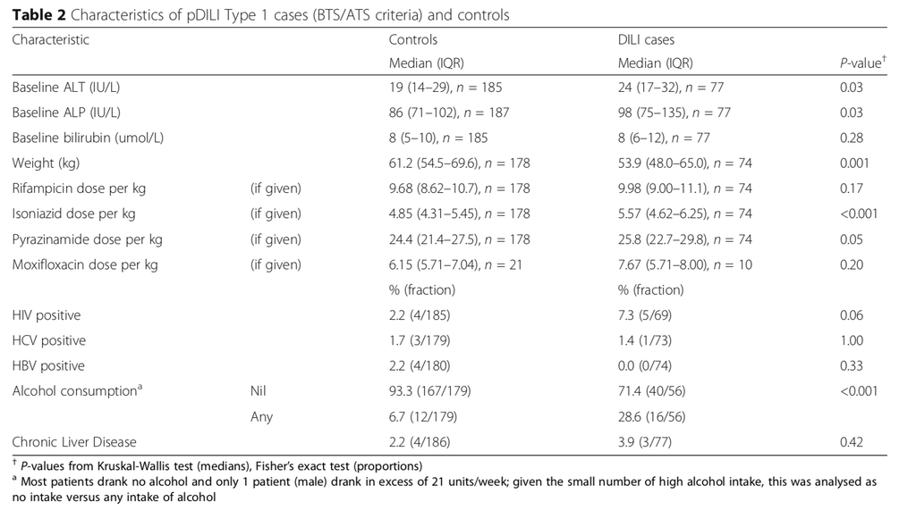

Numeric characteristics from Table 2

As an example let’s reproduce the `weight` and `Moxifloxacin` summaries. First we gather the variables :

```r
df %>%
  gather(key='characteristic', value='value', c(moxi_dpw, weight)) %>%
  select(c(t1dili, characteristic, value)) %>%
  group_by(t1dili, characteristic) %>% head()
```

| t1dili | characteristic | value |
| --- | --- | --- |
| 1 | moxi_dpw | NA |
| 1 | moxi_dpw | NA |
| 0 | moxi_dpw | NA |
| 1 | moxi_dpw | 4.819277 |
| 1 | moxi_dpw | 5.249344 |
| 1 | moxi_dpw | NA |

As each characteristic is a continuous variable - we don’t need to group by the `level` (we’d get a level for every value). Once grouped we can use `summarise` with the `median` and `n()` functions for the median and number of observations, respectively:

```r
df %>%
  gather(key='characteristic', value='value', c(moxi_dpw, weight)) %>%
  select(c(t1dili, characteristic, value)) %>%
  group_by(t1dili, characteristic) %>%
  summarise(n_obs=n(), median=median(value))
```

| t1dili | characteristic | n_obs | median |
| --- | --- | --- | --- |
| 0 | moxi_dpw | 228 | NA |
| 0 | weight | 228 | NA |
| 1 | moxi_dpw | 77 | NA |
| 1 | weight | 77 | NA |

Something’s gone wrong here - we haven’t accounted for the missing values, the `NA`s. Both functions have included them by default. In both cases the missing values count as an observation: if `x = c(1, 2, 3, NA)` then `n_obs(x) = 4` and `median(x) = NA`.

To get around this, we use the `na.rm` option for the median. The number of non-`NA` observations, we convert the `value` to a `TRUE/FALSE` depending on whether it is/isn’t a `NA` using `is.na`. Then we take the negation of this (`!is.na`) so that we have `TRUE/FALSE` if it isn’t/is a `NA`. Then we sum these, as `TRUE=1` AND `FALSE=0`.

```r
df %>%
  gather(key='characteristic', value='value', c(moxi_dpw, weight)) %>%
  select(c(t1dili, characteristic, value)) %>%
  group_by(t1dili, characteristic) %>%
  summarise(n_obs=sum(!is.na(value)), median=median(value, na.rm=TRUE))
```

| t1dili | characteristic | n_obs | median |
| --- | --- | --- | --- |
| 0 | moxi_dpw | 21 | 6.153846 |
| 0 | weight | 205 | 61.000000 |
| 1 | moxi_dpw | 10 | 7.666887 |
| 1 | weight | 74 | 53.850000 |